# Phase 2 - Sensitivity Analysis

Timothy Adams, Patrick Ray

August 1, 2016

# Phase 2 - Sensitivity Analysis

## Overview

Having exited Phase 1, we have already *classified* and *categorized* our project, and identified it as potentially sensitive to climate change. In Phase 2, we take a step back from climate change and answer a more fundamental question: **is the success of this project relatively or significantly sensitive to changes in streamflow?** Breaking down the different parts of this question will help us understand how to approach Phase 2, and what we can expect as a result at the end.

First, we are **interested in changes in streamflow, rather than changes in climate** (e.g. temperature, precipitation, or other climatic variables). Focusing our attention on streamflow allows us to avoid having to create a hydrologic model before we conduct a sensitivity analysis, which saves significant time at this stage. Because climate and streamflow are often tightly linked, we can safely use sensitivity to streamflow as a proxy for sensitivity to climate.

Next, we must **determine what it means to have a successful project**. In Phase 2, this requires choosing a performance metric that we will use to evaluate project outcomes. This could be the NPV of the project, its reliability or safe yield, or anything else.

After choosing a performance metric, we must **choose other key, non-climatic factors to evaluate in addition to streamflow**. This will allow us to make comparisons of the project’s sensitivity to different factors, and, especially, evaluate its sensitivity to streamflow in the proper context.

Next, we must **decide what ranges to explore for each factor**. Should we consider a streamflow range of -30% to +30% from the historical norm, or +/- 50%? Is there a potential for population to grow by 50%, or even to double? These questions are crucial, as the ranges we choose are the largest contributor to the final results of our sensitivity analysis.

Finally, we have to **define the equations that relate each factor to our performance metric**. These equations may only be rough approximations and will be fine-tuned if needed later in the process, but they should be close enough to give a sense of the real picture.

Once we have all of this information, we can **conduct a “one-at-a-time” sensitivity analysis**, varying one factor at a time within our defined ranges to see how changes in that factor affect our performance metric. It follows, then, that we must also pick sensible base values for each factor, so that we can hold all but one factor constant.

Ultimately, the most important output we receive from Phase 2 is a box plot which details the **results** of our sensitivity analysis.

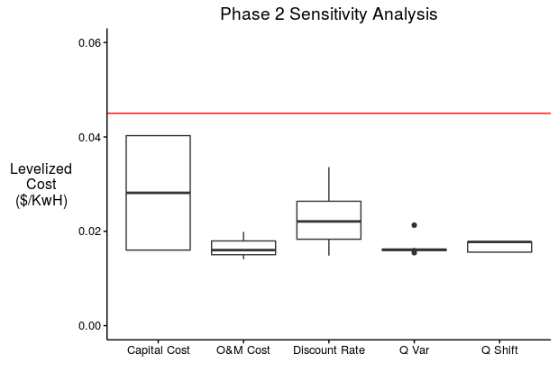

Example of sensitivity analysis result

On this plot, we have each factor plotted on the x-axis, with our performance metric plotted on the y-axis. The boxes define the sensitivity of the performance metric to variations in that factor. (For more information on how to read a box plot, [see this article.](http://www.wellbeingatschool.org.nz/information-sheet/understanding-and-interpreting-box-plots)) If our box for streamflow is sufficiently large compared those of the other factors, than we may decide that we should move to Phase 3 and perform a climate stress test. If, however, our box for streamflow is very small compared to other, non-climatic, factors, then the focus of our future work should be spent understanding and minimizing the uncertainty of those other factors, rather than focusing on climate.

Phase 2 differs from Phase 1 in that we must begin collecting data about the project to conduct our analysis. This data gathering is a crucial component of Phase 2, and requires collaboration from all stakeholders.

The rest of this document describes each step required for Phase 2. We explain how each step contributes to our final product (the box plot displaying the results of our sensitivity analysis) Throughout, we use an example run of the river hydropower plant located in Southern Asia to illustrate some of the actions that will be taken at each step. The appendix contains the R code used to perform the sensitivity analysis, and is provided as an outline which can be adapted for your own project.

## Step 1: Define the skeleton of our analysis

Before we begin collecting any data, we must first determine what to collect data *on*. This requires:

- Defining the factors we wish to perform our sensitivity analysis on. This will certainly include streamflow, but will also include several non-climatic factors.
- Defining the performance metric we will use to evaluate our project.

These definitions are best performed in the context of a stakeholder meeting, with all relevant parties involved. For our example project, we selected the levelized cost of energy as our performance metric, and capital cost, O&M cost, and discount rate as our non-climatic factors. Due to the nature of the monsoon season in Southern Asia and its effect on hydropower, for streamflow we decided to examine both shifts in mean streamflow throughout the year (Q Shift), and shifts in variability of that streamflow (Q Var).

After Step 1 has been completed, we have all we need to define our plot axes. The rest of the steps will help us to fill in the plot with actual results.

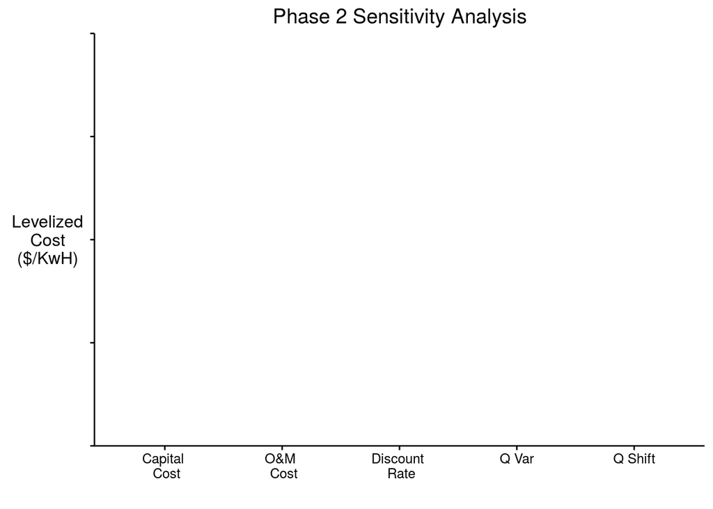

## Step 2: Gather design data and define ranges for sensitivity analysis

Now that we have decided what factors to focus on for our sensitivity analysis, we must begin collecting data. To evaluate our project, we first have to gather fundamental information on its design. This information has often already been compiled in previous consultancy or feasibility studies, and so this step primarily consists of collecting all of the relevant data from these reports and storing it in one centralized place.

Beyond gathering design data, we have to define the ranges we will use to perform our sensitivity analysis on. *How large or small we define the ranges will affect the result of our sensitivity analysis more than any other factor*. If a very large range is chosen for a given factor, that factor will most likely dominate the result, and vice versa for a very small range. For this reason, these ranges should be carefully chosen based on two factors: the current best expert knowledge on what values each factor might take, and the amount of uncertainty in this expert knowledge. It is generally best to err on the side of caution and choose a larger range than is expected, to avoid assumptions from guiding a project away from progressing to Phase 3.

The information to define ranges often comes from a variety of sources. For factors that relate to the construction or operation of the project, consultancy or feasibility studies may include the required information. For other non-climatic factors (e.g. population growth), a national water plan, if one exists, is often the best source. These water plans may also provide insight for how wide our streamflow range should be.

## Step 3: Gather streamflow and climate data

Step 3 runs parallel to step 2 and involves collecting historical streamflow, weather, and climate data. Technically, only streamflow data is required for this step, as we will not use any other climate data for our ultimate sensitivity analysis. However, if there is a reasonable expectation that the project will need to continue to Phase 3 of the Decision Tree Framework, collecting weather and climate data at this time is often the most convenient.

Sources for this kind of data can vary greatly depending on the region and project of interest. Agencies like NOAA offer globally gridded data-sets, which can offer coarse data at the scale of several hundred square kilometers. For more fine-grained data, often a national meteorological service exists provides local weather and climate data. In almost all cases, however, the most expedient way to collect this information will be to meet with the stakeholders, who will be more familiar with their own region’s data collection efforts and will have easier access to this data.

For our example project, we collected streamflow data from 1985-2006 and prepared the data for use by removing missing values and obvious data entry errors. We can combine this data with our design information of our hydropower plant to calculate the energy produced on any date within our historical range (1985-2006), which we need in order to calculate the levelized cost of energy for our hydropower plant.

## Step 4: Define equations that relate factors with our performance metric

Now that we have all of our data, we need to relate each factor to our performance metric. The equations to do this should be relatively simple. Because of this, they will likely not be completely accurate – but this is expected. Our goal here is only to generate an approximation of the project’s true sensitivity to each variable.

The equations that we will create will frequently incorporate the design information of the project itself. They might even be included in any feasibility studies already created for the project. For our example project, we calculated 5 equations to relate each of our variables (capital cost, O&M cost, discount rate, Q Var, and Q Shift) to levelized cost of electricity.

## Step 5: Conduct a sensitivity analysis

With all of our data collected and our equations defined, we can conduct our actual sensitivity analysis. This follows a basic algorithm:

1. Set base values for each factor.
2. For the first factor, create an array of values that cover the range defined for that factor.
3. Feed each value in the array created in 2 into the equation defined for that factor, along with the base values for all of the other factors. This will create an array of your performance metric that results from the range of values for your chosen factor.
4. Repeat 2 and 3 for each factor.
5. With the data produced from 1-4, produce a box plot.

The final result for our example project is shown in the plot below.

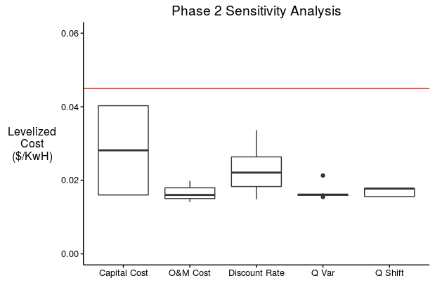

Final result of sensitivity analysis

## Step 6: Conclude whether or not to proceed to Phase 3

The final step consists of analyzing the box plot to identify whether or not this project warrants proceeding to Phase 3. If we examine the result from our example project, we see that, with the ranges that we chose, our performance metric is most sensitive to capital cost and discount rate. Neither the ranges chosen for Q Var or Q Shift result in a relatively significant change in our performance metric. Due to this, it would be reasonable to conclude that Phase 3 is not necessary for this project, opting instead to devote resources toward a more detailed analysis of capital cost and discount rate.

# Appendix: Example Code

This code provides an example sensitivity analysis performed for a run of the river hydropower plant. You can use this to provide a rough outline for your own work.

```r
# install packages required for our analysis
if (!require("pacman")) install.packages("pacman") # package managment tool
pacman::p_load(dplyr, reshape2, stringr, ggplot2, scales, ggthemes)

# -----------------------------------------------------------------------------
# STEP 1: Define the skeleton of our analysis

# The code in this step code generates the figure shown in step 1. It is not
# necessary to conducting the final sensitivity analysis.

# Create a dummy data frame that contains our different factors
sens_analysis <- data.frame(capital.cost = 1, om.cost = 1, dscnt.rate = 1, q.var = 1, q.shift = 1)
sens_analysis <- melt(as.data.frame(sens_analysis), variable.name = "factor")

# Create an empty plot with our factors on the x-axis and our performance metric
# on the y-axis.
empty_plot <- ggplot(sens_analysis, aes(factor(factor), value)) + geom_blank() +
  scale_x_discrete(labels = c("Capital \n Cost", "O&M \n Cost", "Discount \n Rate", "Q Var", "Q Shift"))    +
  scale_y_continuous(breaks = waiver(), labels = NULL) +
  labs(list(title = "Phase 2 Sensitivity Analysis", x = "", y = "Levelized\nCost\n($/KwH)")) +
  theme_classic() +
  theme(axis.title.y = element_text(angle = 0),
        axis.line.x = element_line(colour = 'black', linetype = 'solid'),
        axis.line.y = element_line(colour = 'black', linetype = 'solid'))


# -----------------------------------------------------------------------------
# STEP 2: Gather design data and define ranges for sensitivity analysis

# Design parameters for 335 MW hydropower plant @ Q70
mw_cap        <- 335            # capacity of dam, in MW
cost_cap_base <- 450e6          # capital cost, in dollars
t_constr      <- 60             # ??? construction time in months (5 yrs)
H             <- 492            # hydraulic head, in meters
e             <- 0.9            # plant efficiency - unknown, but assume 90%

# unit conversion
kwhr_cap      <- mw_cap*24*1000 # kWhr capacity per day for Q70

# Set baselines for factors
dis_rate_base   <- 0.05
cost_om_base    <- 2*(125000*(kwhr_cap/1000/24)^0.65) # annual O&M cost

# Set ranges for factors
cost_cap_range  <- cost_cap_base * c(1, 2, 3) # capital cost can be up to 3 times the base
dis_rate_range  <- c(dis_rate_base, 0.07, 0.10, 0.12) # annual discount rate between 5-12%
cost_om_range   <- c(seq(0.5, 1, 0.05), seq(1.1, 2, 0.1)) * cost_om_base # O&M range
 # streamflow...?

#### Other constants
price           <- 0.045        # price of electricity in Nepal in Nepalese Rupees per KWh
econ_life       <- 30*12        # economic lifetime, in months AFTER end of construction
sec_per_day     <- 60*60*24
sec_per_hour    <- 60*60

# -----------------------------------------------------------------------------
# STEP 3: Gather streamflow and climate data

# Get historical streamflow data
strmflw <- read.csv("streamflow.csv", header = TRUE)
print(strmflw)
```

```
##      Year Month Day Streamflow..m3.s. Streamflow..MCM.
## 1    1985   Apr  15             102.0          8.81280
## 2    1985   Apr  16             102.0          8.81280
## 3    1985   Apr  17              94.3          8.14752
## 4    1985   Apr  18              92.1          7.95744
## 5    1985   Apr  19              92.1          7.95744
## 6    1985   Apr  20             102.0          8.81280
## 7    1985   Apr  21             102.0          8.81280
## 8    1985   Apr  22             117.0         10.10880
## 9    1985   Apr  23             103.0          8.89920
## 10   1985   Apr  24             102.0          8.81280
## 11   1985   Apr  25             102.0          8.81280
## 12   1985   Apr  26             102.0          8.81280
## 13   1985   Apr  27             102.0          8.81280
## 14   1985   Apr  28              99.8          8.62272
```

[output cut: 1987 more lines]

```r
# Remove missing values
miss_val      <- which(is.na(strmflw[, 4]))
strmflw <- strmflw[-miss_val, ]

q <- strmflw[, 4] # daily streamflow in m3/s

# Equation below comes from Loucks and Van Beek, page 359, equation 11.70
# (ISBN: 92-3-103998-9)
# KWHt <- 9.81*q*H*(seconds per time interval)*e/(seconds per hour)

KWH <- 9.81*q*H*e*sec_per_day/sec_per_hour # theoretical kilowatt-hrs produced, daily
arun_hydro <- cbind(strmflw, KWH)

# We can't produce more kilowatt-hrs than our dam has capacity for. Therefore,
# we need to cap our theoretical yield if it exceeds our capacity.
energy_day <- sapply(arun_hydro[, 6], function(x) min(x, kwhr_cap))
arun_hydro[, 7] <- energy_day
colnames(arun_hydro) <- c("Year","Month","Day","m3s","MCM","KWH","KWHcap")


# -----------------------------------------------------------------------------
# STEP 4: Define equations that relate factors with our performance metric
# AND
# STEP 5: Conduct a sensitivity analysis
# (Note: Steps 4 and 5 are largely lumped together in
#  the code below. The reader is encouraged to either combine these steps or
#  separate them out in their implementation depending on their own
#  preference.)

# compute levelized cost of energy (LCE)
# cap_cost         : A number or vector of numers representing the capital cost
#                    of the project.
# cost_om_pres_val : A number or vector of numbers that represent the present
#                    value of the cost of O&M across ALL years.
# energy_pres_val  : a vector of numbers that represent the present value
#                    of the amount of energy generated across ALL years.
lce <- function(cap_cost, cost_om_pres_val, energy_pres_val) {
  (cap_cost + cost_om_pres_val) / (energy_pres_val)
}

years <- 1:length(unique(arun_hydro[,1]))
print(years)
```

```
##  [1]  1  2  3  4  5  6  7  8  9 10 11 12 13 14 15 16 17 18 19 20 21 22
```

```r
strmflw_ann <- as.matrix(group_by(arun_hydro, Year) %>% summarize(flow = sum(MCM)))
print(strmflw_ann)
```

```
##       Year      flow
##  [1,] 1985  9584.456
##  [2,] 1986  8934.659
##  [3,] 1987 10015.091
##  [4,] 1988 10340.309
##  [5,] 1989  9444.228
##  [6,] 1990  8964.276
##  [7,] 1991  9600.137
##  [8,] 1992  7419.254
##  [9,] 1993  7717.645
## [10,] 1994  7433.260
## [11,] 1995  9823.257
## [12,] 1996  9062.859
## [13,] 1997  7085.992
## [14,] 1998  9761.247
## [15,] 1999 10263.154
## [16,] 2000  9483.186
## [17,] 2001  7259.907
## [18,] 2002  6795.239
## [19,] 2003  6504.857
## [20,] 2004  6539.452
## [21,] 2005  5746.058
## [22,] 2006  6070.317
```

```r
energy_ann  <- as.matrix(group_by(arun_hydro, Year) %>% summarize(energy = sum(KWHcap)))

print(energy_ann)
```

```
##       Year     energy
##  [1,] 1985 2098440000
##  [2,] 1986 2927282910
##  [3,] 1987 2898256167
##  [4,] 1988 2899888831
##  [5,] 1989 2912003442
##  [6,] 1990 2902618041
##  [7,] 1991 2873423142
##  [8,] 1992 2861448381
##  [9,] 1993 2872768024
## [10,] 1994 2808239087
## [11,] 1995 2810964623
## [12,] 1996 2854617390
## [13,] 1997 2727524222
## [14,] 1998 2740366496
## [15,] 1999 2934587468
## [16,] 2000 2938456707
## [17,] 2001 2898007959
## [18,] 2002 2898673286
## [19,] 2003 2830217906
## [20,] 2004 2716218137
## [21,] 2005 2794718953
## [22,] 2006 2791877388
```

```r
# energy_ann_avg  <- mean(energy_ann[, 2])

# energy_pres_val <- energy_ann_avg*(1+dis_rate_base)^(-years)
# cost_om_pres_val <- cost_om_base*(1+dis_rate_base)^(-years)
#
# # Capital cost sensitivity
# LCE_capital_cost <- lce(cost_cap_range,
#                         sum(cost_om_pres_val),
#                         sum(energy_pres_val))
#
# # O&M cost sensitivity
# cost_om_pres_val_range <- array(NA, c(length(years), length(cost_om_range)))
# for (i in 1:length(cost_om_range)) {
#   cost_om_pres_val_range[,i] <- cost_om_range[i]*(1+dis_rate_base)^(-years)
# }
# sum_cost_om_pres_val <- apply(cost_om_pres_val_range, MARGIN=2, sum)
# LCE_om <- lce(cost_cap_base,
#               sum_cost_om_pres_val,
#               sum(energy_pres_val))

# # Discount rate sensitivity
# energy_pres_val_range <- array(NA, c(length(years), length(dis_rate_range)))
# for (i in 1:length(dis_rate_range)) {
#   energy_pres_val_range[,i] <- energy_ann_avg*(1+dis_rate_range[i])^(-years)
#   cost_om_pres_val_range[,i] <- cost_om_base*(1+dis_rate_range[i])^(-years)
# }
# sum_energy_pres_val <- apply(energy_pres_val_range, MARGIN=2, sum)
# sum_cost_om_pres_val <- apply(cost_om_pres_val_range, MARGIN=2, sum)
# LCE_dscnt <- lce(cost_cap_base,
#                  sum_cost_om_pres_val,
#                  sum_energy_pres_val)
#
# # Streamflow variability sensitivity
# num_stoch <- 19
# energy_stoch_1st <- seq(min(energy_ann[,2]), max(energy_ann[,2]),
#                         (max(energy_ann[,2])-min(energy_ann[,2]))/(econ_life-1))
# energy_stoch_last <- seq(max(energy_ann[,2]), min(energy_ann[,2]),
#                          -(max(energy_ann[,2])-min(energy_ann[,2])) / (econ_life-1))
# energy_stoch <- array(NA,c(length(years),num_stoch))
# for (i in 1:num_stoch) {
#   order <- sample(1985:2006,length(years),replace=T)
#   energy_stoch[,i] <- energy_ann[sapply(order, function(x) which(energy_ann[,1] == x)),2]
# }
# energy_range <- cbind(energy_stoch_1st,energy_stoch,energy_stoch_last)
# energy_range_pres_val <- array(NA,c(length(years),dim(energy_range)[2]))
# for (i in 1:dim(energy_range)[2]) {
#   energy_range_pres_val[,i] <- energy_range[,i]*(1+dis_rate_base)^(-years)
# }
# sum_energy_range_pres_val <- apply(energy_range_pres_val,MARGIN=2,sum)
# LCE_qvar <- lce(cost_cap_base,
#                 sum(cost_om_pres_val),
#                 sum_energy_range_pres_val)
#
# # Streamflow mean sensitivity
# sd_flow <- sd(strmflw_ann[,2])
# mean_flow <- mean(strmflw_ann[,2])
# cv_strmflw_ann <- sd_flow / mean_flow
# #sd(strmflw[,5])/mean(strmflw[,5]) #check cv of daily streamflow - bigger than cv annual
#
# DQ_pos <- ((mean_flow*1.5-mean_flow)/mean_flow) #Either a custom ratio from the stress test or cv_strmflw_ann
# DQ_neg <- ((mean_flow-mean_flow*0.7)/mean_flow) #Either a custom ratio from the stress test or cv_strmflw_ann
# KWH_mcm <- 0.002725*arun_hydro[,5]*H*e*1e6
# high_flow <- arun_hydro[,5]*(1+DQ_pos)
# low_flow <- arun_hydro[,5]*(1-DQ_neg)
# arun_hydro[,8] <- high_flow
# arun_hydro[,9] <- low_flow
# arun_hydro[,10] <- 0.002725*arun_hydro[,8]*H*e*1e6
# arun_hydro[,11] <- 0.002725*arun_hydro[,9]*H*e*1e6
#
# energy_day_high <- sapply(arun_hydro[,10],function(x) min(x,kwhr_cap))
# arun_hydro[,12] <- energy_day_high
# energy_day_low <- sapply(arun_hydro[,11],function(x) min(x,kwhr_cap))
# arun_hydro[,13] <- energy_day_low
# colnames(arun_hydro) <- c("Year","Month","Day","m3s","MCM","KWH","KWHcap","high_flow","low_flow","KWH_high","KWH_low","KWHcap_high","KWHcap_low")
#
# strmflw_ann_high <- as.matrix(group_by(arun_hydro,Year) %>% summarize(flow=sum(high_flow)))
# energy_ann_high <- as.matrix(group_by(arun_hydro,Year) %>% summarize(energy=sum(KWHcap_high)))
# energy_ann_avg_high <- as.numeric(group_by(arun_hydro,Year) %>% summarize(energy=sum(KWHcap_high)) %>% summarize(avg=mean(energy)))
# energy_pres_val_high <- energy_ann_avg_high*(1+dis_rate_base)^(-years)
# LCE_qshift_high <- lce(cost_cap_base,
#                        sum(cost_om_pres_val),
#                        sum(energy_pres_val_high))
#
# strmflw_ann_low <- as.matrix(group_by(arun_hydro,Year) %>% summarize(flow=sum(low_flow)))
# energy_ann_low <- as.matrix(group_by(arun_hydro,Year) %>% summarize(energy=sum(KWHcap_low)))
# energy_ann_avg_low <- as.numeric(group_by(arun_hydro,Year) %>% summarize(energy=sum(KWHcap_low)) %>% summarize(avg=mean(energy)))
# energy_pres_val_low <- energy_ann_avg_low*(1+dis_rate_base)^(-years)
# LCE_qshift_low <- lce(cost_cap_base,
#                       sum(cost_om_pres_val),
#                       sum(energy_pres_val_low))
#
# LCE_qshift <- c(LCE_qshift_low, LCE_qshift_high)
#
# # Create box plot
# sens_analysis <- cbind(LCE_capital_cost, LCE_om, LCE_dscnt, LCE_qvar, LCE_qshift)
# colnames(sens_analysis) <- c("capital.cost","om.cost","dscnt.rate","q.var","q.shift")
# sens_analysis <- melt(as.data.frame(sens_analysis), variable.name = "factor")
#
# plot <- ggplot(sens_analysis, aes(factor(factor), value)) + geom_boxplot() +
#   #theme_classic() +
#   scale_x_discrete(labels=c("Capital Cost", "O&M Cost", "Discount Rate", "Q Var", "Q Shift")) +
#   scale_y_continuous(limits = c(0,0.06)) +
#   labs(list(title = "Phase 2 Sensitivity Analysis", x = "", y = "Levelized\nCost\n($/KwH)")) +
#   theme_classic() +
#   theme(axis.title.y = element_text(angle = 0),
#         axis.line.x = element_line(colour = 'black', linetype = 'solid'),
#         axis.line.y = element_line(colour = 'black', linetype = 'solid')) +
#   geom_hline(yintercept=price, colour = "red")
# plot
```